# Super Stores Analysis

Ezihe Chinonyelum Grace

## Introduction

[figure not shown]

With growing demands and cut-throat competitions in the market, a Superstore Giant is seeking knowledge in understanding what works best for them. They would like to understand which products, regions, categories and customer segments they should target or avoid.

The following report presents an analysis of the SuperStore dataset, which contains sales and customer data.The dataset was sourced from [Kaggle](https://www.kaggle.com/datasets/rohitsahoo/sales-forecasting/download?datasetVersionNumber=2).

The analysis aims to provide insights into the sales performance, profit margins, customer segments, and customer churn for the SuperStore. The analysis was conducted using the R programming language and several data visualization packages, including ggplot2.

## Data Processing

```r
#Loading essential libraries
library(dplyr)
library(tidyr)
library(ggplot2)
library(lubridate)
```

```r
# Load the dataset
df <- read.csv('Superstore.csv', encoding = "latin1")
```

```r
#Data Cleaning
str(df)
dim(df)
sum(is.na(df))
sum(duplicated(df))

#change date columns to datetime format
df$Order.Date <- as.POSIXct(df$Order.Date, format = "%m/%d/%Y")
```

The dataset was loaded from a CSV file, and initial exploratory steps were performed. The dataset contains no missing values or duplicated rows, ensuring data integrity.

## Sales Analyses

### Distribution of Sales

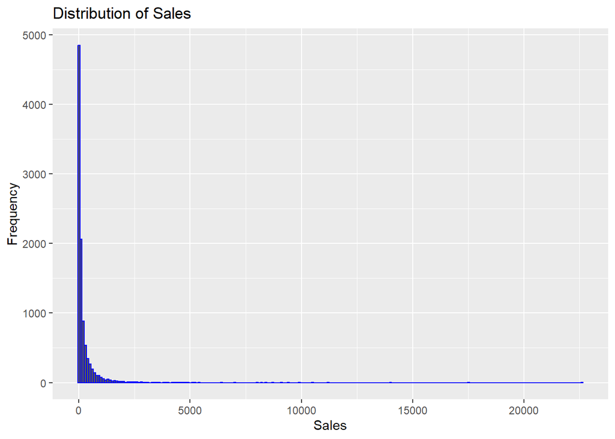

```r
#Histogram of Sales
ggplot(df,aes(x=Sales))+ geom_histogram(binwidth = 100, color ='blue')+
  labs(x= "Sales", y= "Frequency",title = "Distribution of Sales")
```

The histogram of sales distribution revealed that the majority of sales fall within the range of 0 to 2000.

### Sales Trend over the years

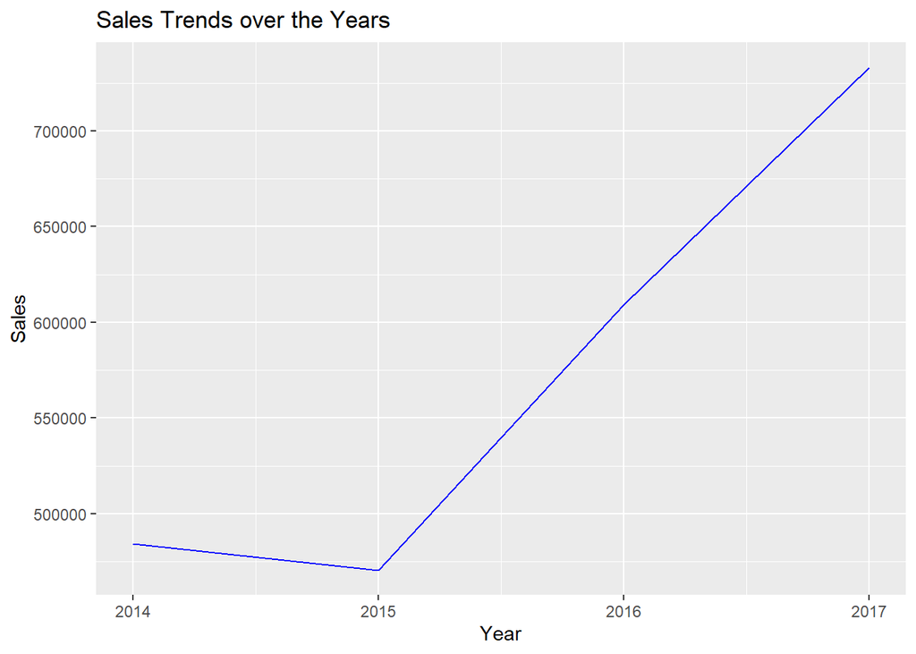

```r
df$year <- year(df$Order.Date)
Sales_by_year = df %>% group_by(year) %>% summarise(Total.Sales = sum(Sales))
ggplot(Sales_by_year, aes(x = year, y = Total.Sales)) +
  geom_line(color = 'blue') +
  labs(x = 'Year', y = 'Sales', title = 'Sales Trends over the Years')
```

In 2015, sales reached their lowest point, but subsequently exhibited a consistent upward trend

### Monthly Sales trend

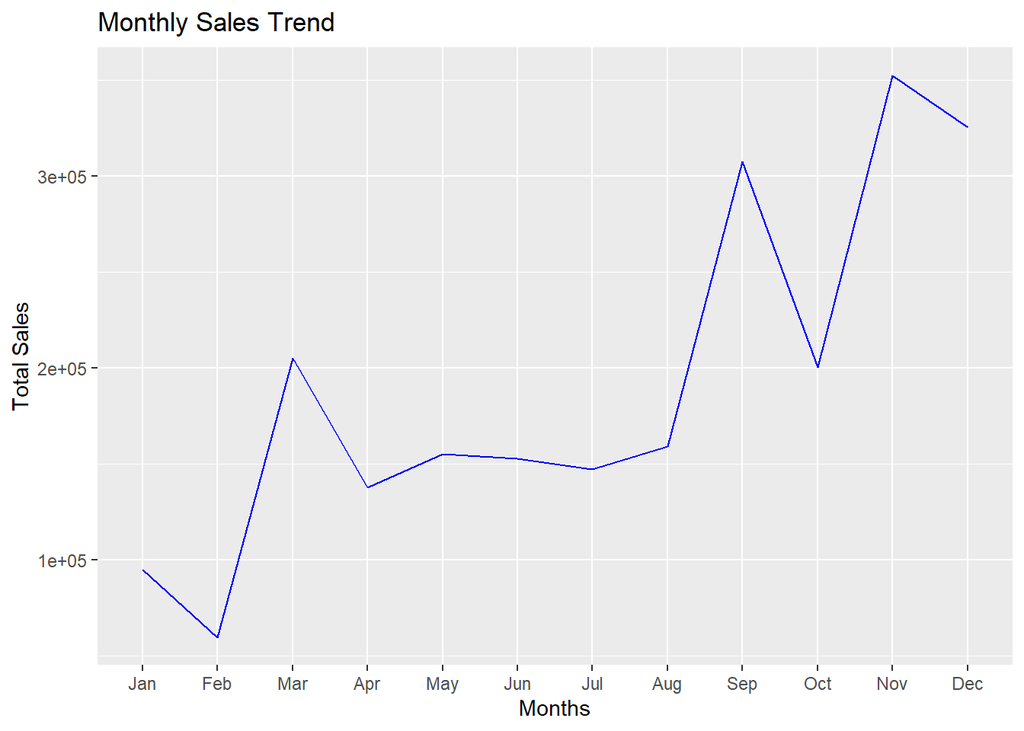

```r
monthly_sales = df %>%
  group_by(Month = format(Order.Date, "%b")) %>%
  summarise(Total.Sales = sum(Sales))

month_order = c("Jan", "Feb", "Mar", "Apr", "May", "Jun", "Jul", "Aug", "Sep", "Oct", "Nov", "Dec")
monthly_sales$Month = factor(monthly_sales$Month, levels = month_order)
ggplot(monthly_sales, aes(x = Month, y = Total.Sales, group = 1)) +
  geom_line(color = 'blue') +
  labs(x = 'Months', y = 'Total Sales', title = 'Monthly Sales Trend')
```

The Monthly sales trend reveals a pattern. In January and February, they’re a bit slow after the holidays. In March and April, sales go up, possibly because of different reasons like better economic conditions or promotions. May and June stay pretty steady, and August sees a small increase. The most interesting part is later in the year. In September, sales shoot up, and they’re even higher in November and December during the holiday season. So, it looks like people tend to spend more around holidays.

### Top Selling Categories, Subcategories and Products

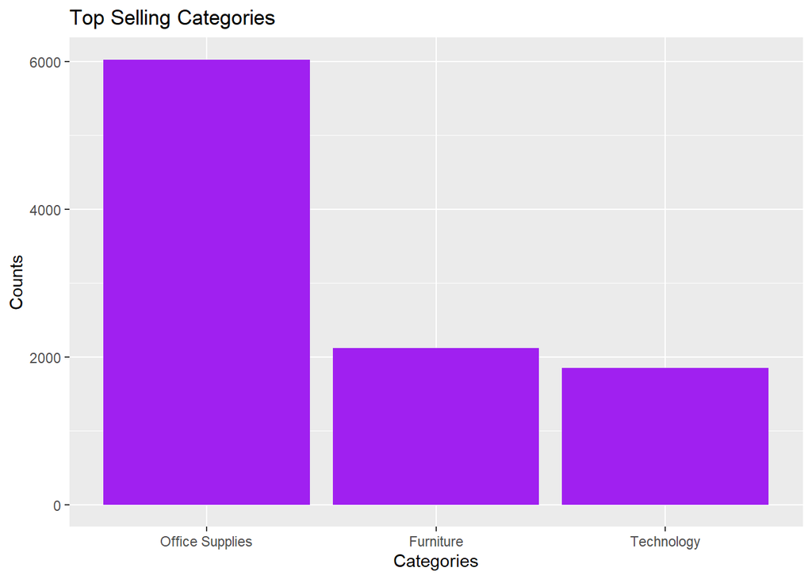

```r
#Top Selling Categories
top_categories = df %>% count (Category)
ggplot(top_categories, aes(x= reorder(Category,-n), y = n))+
  geom_bar(stat='identity',fill='purple')+
  labs(x= 'Categories', y= 'Counts', title = 'Top Selling Categories')
```

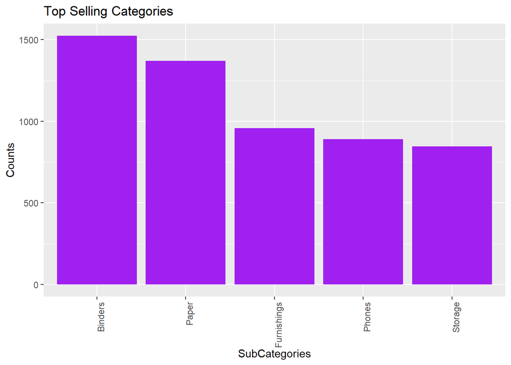

```r
#Top Selling SubCategories
top_Subcategories = df %>% count (Sub.Category) %>%  top_n(5,n)
ggplot(top_Subcategories, aes(x= reorder(Sub.Category,-n), y = n))+
  geom_bar(stat='identity',fill='purple')+
  labs(x= 'SubCategories', y= 'Counts', title = 'Top Selling Categories')+
  theme(axis.text.x = element_text(angle=90, hjust = 1))
```

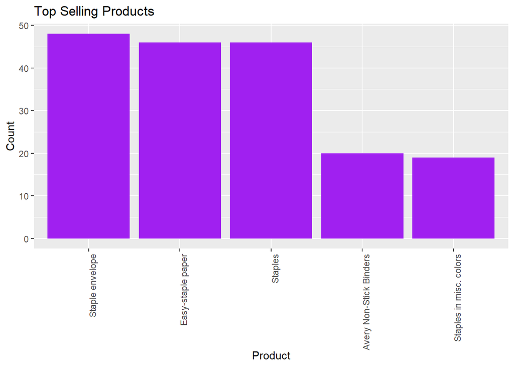

```r
# Top Selling product
top_product = df %>% count(Product.Name) %>%  top_n(5,n)
ggplot(top_product, aes(x= reorder(Product.Name, -n), y =n))+
  geom_bar(stat = 'identity', fill = 'purple')  +
  labs(x ='Product', y= 'Count', title = 'Top Selling Products')+
  theme(axis.text.x = element_text(angle=90, hjust = 1))
```

From the above, in terms of total number of sales, Office supplies emerged as the top-selling category in the product range. Within the office supplies category, the subcategory of binders and papers stood out as the highest-performing subcategory.The top selling products in the inventory include “Staple Envelope,” “Easy-Staple Paper,” and “Staples.”

### Sales by Product Catgory

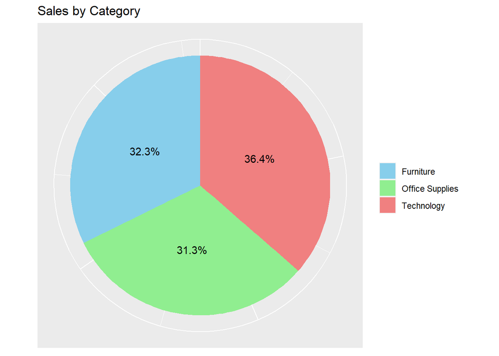

```r
category_sales = df %>% group_by(Category) %>% summarise(Total.sales = sum(Sales))
ggplot(category_sales, aes(x = "", y = Total.sales, fill = Category)) +
  geom_bar(stat = "identity") +
  labs(x = NULL, y = NULL, fill = NULL, title = "Sales by Category") +
  coord_polar(theta = "y") +
  scale_fill_manual(values = c("skyblue", "lightgreen", "lightcoral"))+
  geom_text(aes(label = scales::percent(Total.sales / sum(Total.sales))),
            position = position_stack(vjust = 0.5))+
  theme(axis.text = element_blank(),
        axis.ticks = element_blank())
```

While “Office Supplies” stands out as the top-selling product category, the chart above reveals that the “Technology” category commands the highest sales figures among all product categories.

### Sales by Region

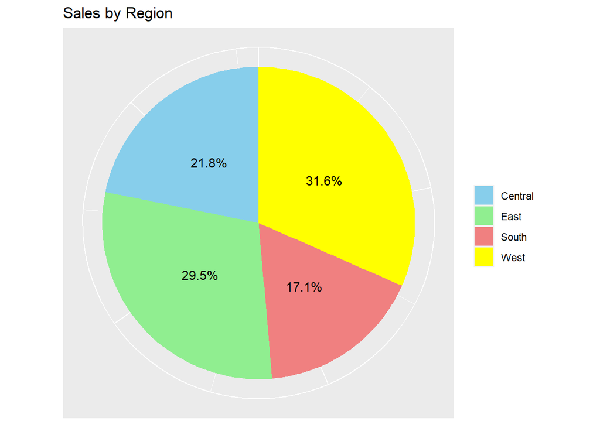

```r
region_sales <- df %>% group_by(Region) %>% summarise(Total.sales = sum(Sales))
ggplot(region_sales, aes(x = "", y = Total.sales, fill = Region)) +
  geom_bar(stat = "identity") +
  labs(x = NULL, y = NULL, fill = NULL, title = "Sales by Region") +
  coord_polar(theta = "y") +
  scale_fill_manual(values = c("skyblue", "lightgreen", "lightcoral", "yellow"))+
  geom_text(aes(label = scales::percent(Total.sales / sum(Total.sales))),
            position = position_stack(vjust = 0.5))+
  theme(axis.text = element_blank(),
        axis.ticks = element_blank())
```

The Western region is leading in terms of sales performance, followed by the Eastern and Central regions. The Southern region records the lowest sales figures.

### Sales by State

```r
State_sales = df %>% group_by(State) %>% summarise(Total.sales = sum(Sales)) %>%
  arrange(desc(Total.sales)) %>%top_n(10)
```

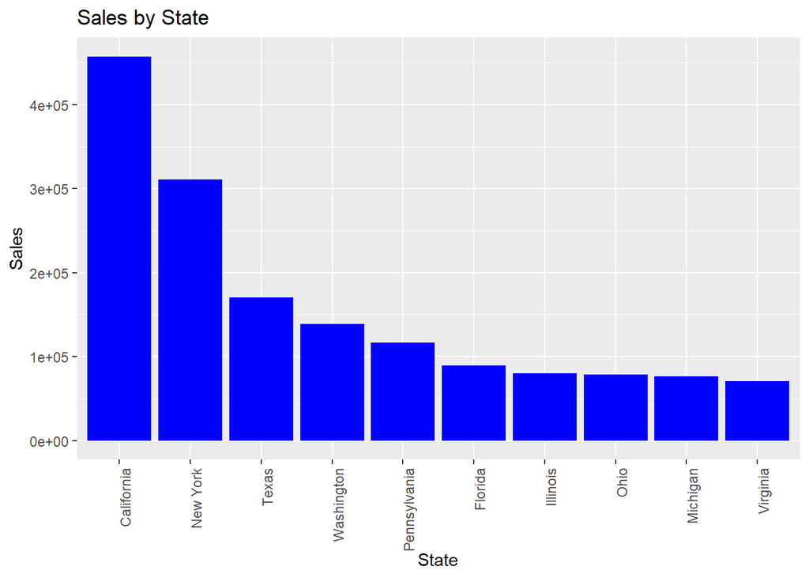

```r
ggplot(State_sales, aes(x= reorder(State, -Total.sales), y =Total.sales))+
  geom_bar(stat = 'identity', fill = 'blue')  +
  labs(x ='State', y= 'Sales', title = 'Sales by State')+
  theme(axis.text.x = element_text(angle=90, hjust = 1))
```

California has the highest sale figure, followed by New York, then Texas

### Sales by City

```r
City_sales = df %>% group_by(City) %>% summarise(Total.sales = sum(Sales)) %>%
  arrange(desc(Total.sales)) %>%top_n(10)
```

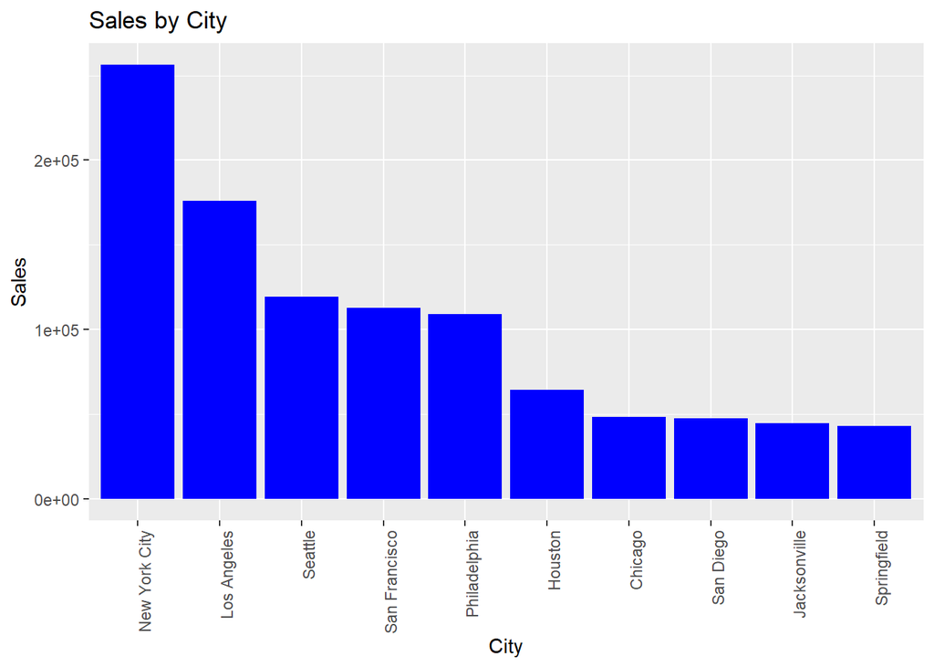

```r
ggplot(City_sales, aes(x= reorder(City, -Total.sales), y =Total.sales))+
  geom_bar(stat = 'identity', fill = 'blue')  +
  labs(x ='City', y= 'Sales', title = 'Sales by City')+
  theme(axis.text.x = element_text(angle=90, hjust = 1))
```

New York city is the highest in terms of sales figure, followed by Los Angeles and Seattle

### Correlation Analysis

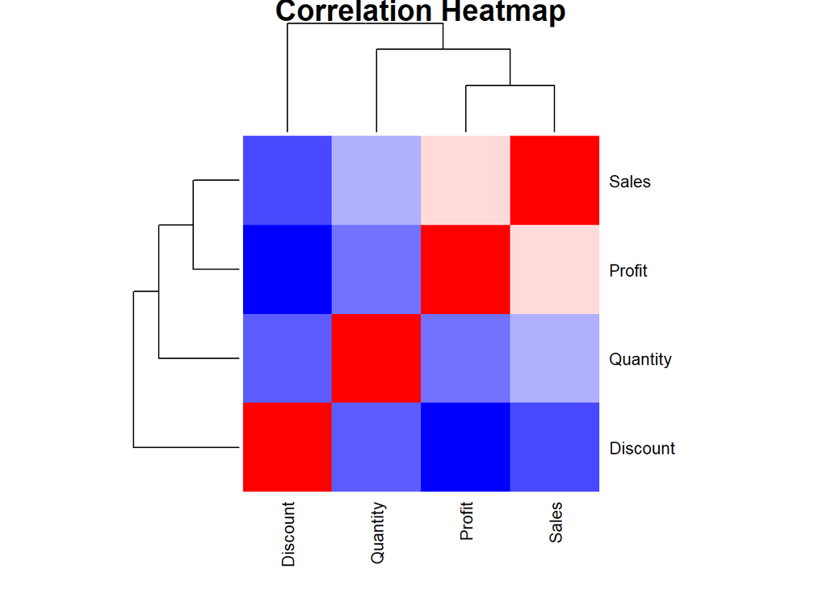

```r
correlation = cor(df[c('Sales', 'Profit', 'Quantity', 'Discount')])
heatmap(correlation, main = 'Correlation Heatmap',col = colorRampPalette(c("blue", "white", "red"))(50),
        scale = "none",cexCol = 1, cexRow = 1,margins = c(5, 5))
```

In the correlation analysis above, notably, a moderate positive correlation is observed between Sales and Profit, suggesting that as Sales increase, Profit tends to rise as well, which can be a critical insight for enhancing profitability. Additionally, Sales and Quantity exhibit a weaker positive correlation, indicating a subtle tendency for Quantity to increase with Sales. Conversely, the correlation between Profit and Quantity is minimal, implying that other factors beyond Quantity have a more substantial influence on Profit.

## Profit Analysis

### Profit Trends over Time

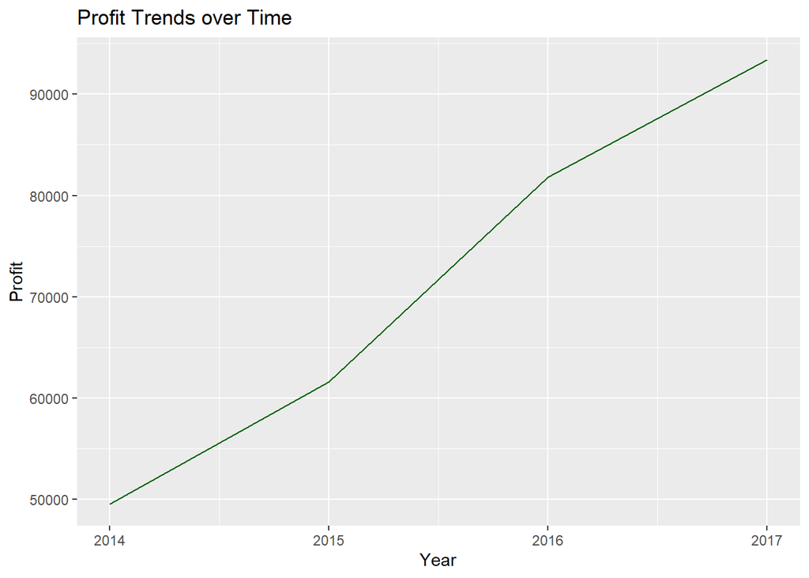

```r
profit_by_year = df %>% group_by(year) %>% summarise(Total.Profit = sum(Profit))
ggplot(profit_by_year, aes(x = year, y = Total.Profit)) +
  geom_line(color = 'darkgreen') +
  labs(x = 'Year', y = 'Profit', title = 'Profit Trends over Time')
```

Profit tends to increase over the years

### Pofit margin by category

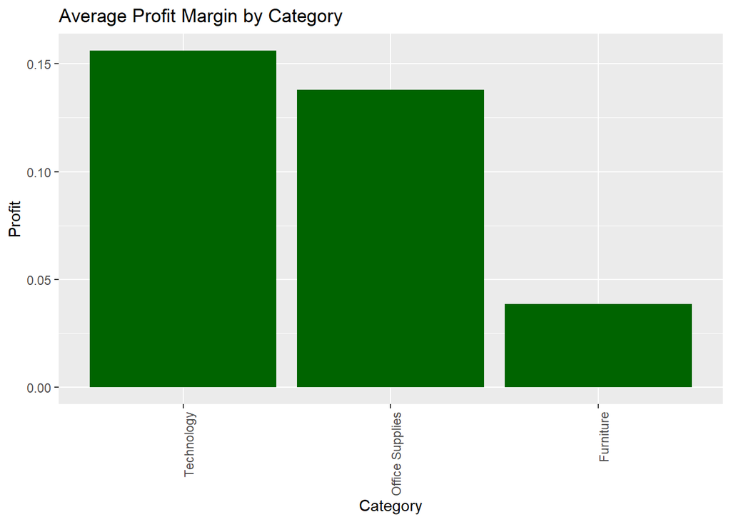

```r
df$Profit.Margin = df$Profit / df$Sales
category_profit_margin = df %>% group_by(Category) %>% summarise(Avg.Profit.Margin = mean(Profit.Margin))

ggplot(category_profit_margin, aes(x= reorder(Category, -Avg.Profit.Margin), y =Avg.Profit.Margin))+
  geom_bar(stat = 'identity', fill = 'darkgreen')  +
  labs(x ='Category', y= 'Profit', title = 'Average Profit Margin by Category')+
  theme(axis.text.x = element_text(angle=90, hjust = 1))
```

Examining the profitability across different product categories, Technology category has the highest profit margins, followed by Office Supplies, and lastly, Furniture, which exhibits comparatively lower profit margins.

### Profit Magin by region

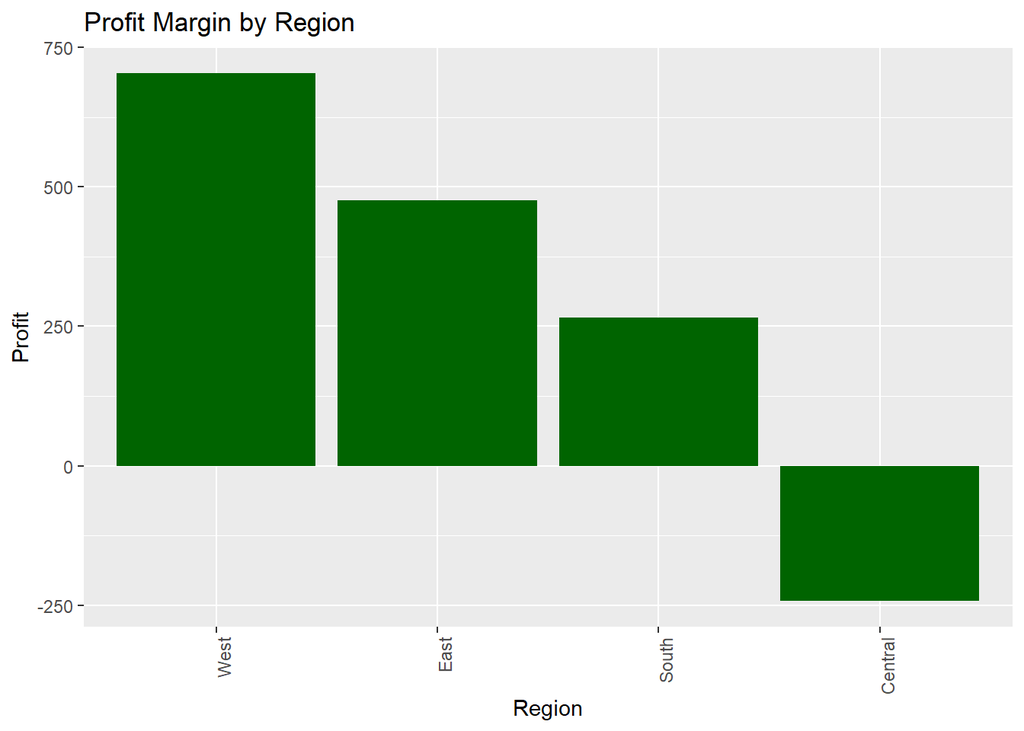

```r
region_profit_margin = df %>% group_by(Region) %>% summarise(Total.Profit.Margin = sum(Profit.Margin))

ggplot(region_profit_margin, aes(x= reorder(Region, -Total.Profit.Margin), y =Total.Profit.Margin))+
  geom_bar(stat = 'identity', fill = 'darkgreen')  +
  labs(x ='Region', y= 'Profit', title = 'Profit Margin by Region')+
  theme(axis.text.x = element_text(angle=90, hjust = 1))
```

The analysis of profit margins across different regions reveals varying profitability levels. The West region exhibits the highest profitability, followed by the East and South regions, while the Central region shows a lower and negative profitability level. These regional differences in profitability suggest potential opportunities for strategic adjustments and resource allocation to enhance overall profitability.

### Profit Margin by State

```r
State_profit_margin = df %>% group_by(State) %>% summarise(Total.Profit.Margin = sum(Profit.Margin))%>% arrange(desc(Total.Profit.Margin)) %>%top_n(10)
```

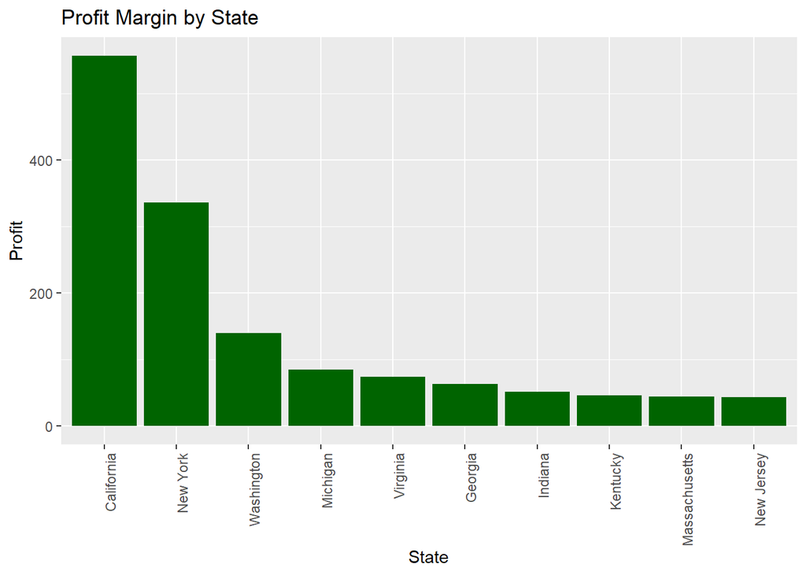

```r
ggplot(State_profit_margin, aes(x= reorder(State, -Total.Profit.Margin), y =Total.Profit.Margin))+
  geom_bar(stat = 'identity', fill = 'darkgreen')  +
  labs(x ='State', y= 'Profit', title = 'Profit Margin by State')+
  theme(axis.text.x = element_text(angle=90, hjust = 1))
```

California brings the highest profit, followed by New York and Washington

### Profit Margin by City

```r
City_profit_margin = df %>% group_by(City) %>% summarise(Total.Profit.Margin = sum(Profit.Margin))%>% arrange(desc(Total.Profit.Margin)) %>%top_n(10)
```

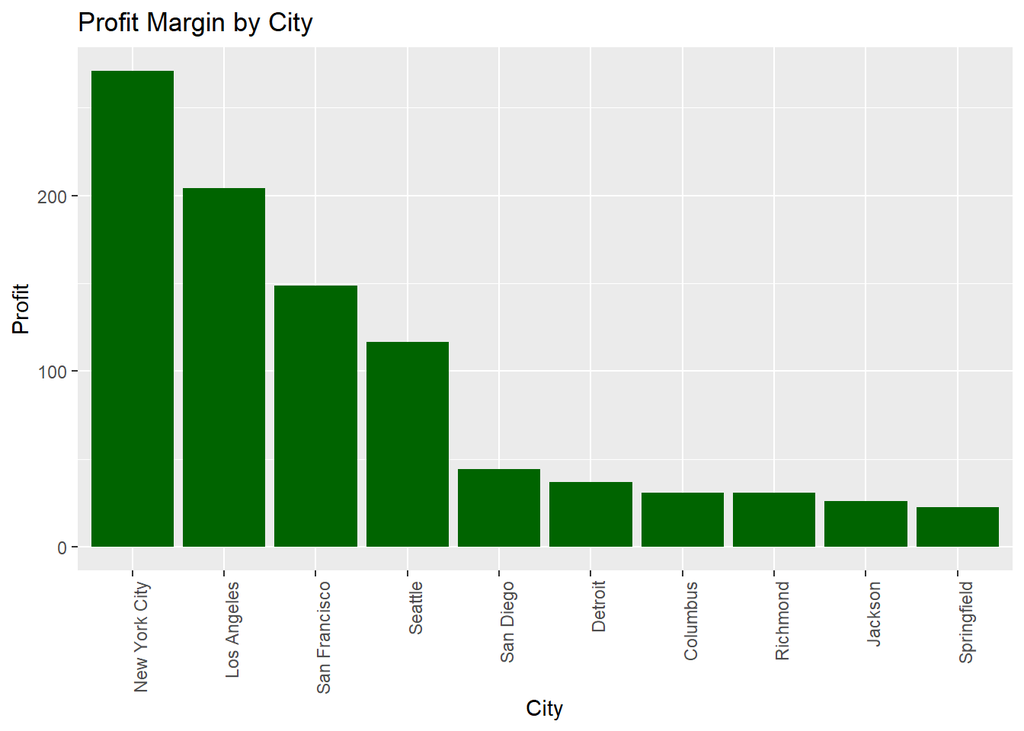

```r
ggplot(City_profit_margin, aes(x= reorder(City, -Total.Profit.Margin), y =Total.Profit.Margin))+
  geom_bar(stat = 'identity', fill = 'darkgreen')  +
  labs(x ='City', y= 'Profit', title = 'Profit Margin by City')+
  theme(axis.text.x = element_text(angle=90, hjust = 1))
```

New York City brings the highest profit, followed by Los Angeles and San Francisco

### Profit by customer segment

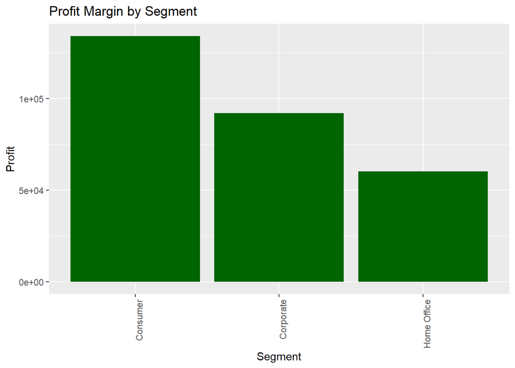

```r
segment_profit <- df %>% group_by(Segment) %>% summarise(Total.Profit = sum(Profit))

ggplot(segment_profit, aes(x= reorder(Segment, -Total.Profit), y =Total.Profit))+
  geom_bar(stat = 'identity', fill = 'darkgreen')  +
  labs(x ='Segment', y= 'Profit', title = 'Profit Margin by Segment')+
  theme(axis.text.x = element_text(angle=90, hjust = 1))
```

Across different customer segments, the Consumer segment has the highest total profit, followed by the Corporate and Home Office segments

## Customer Analysis

### Top purchasing segment

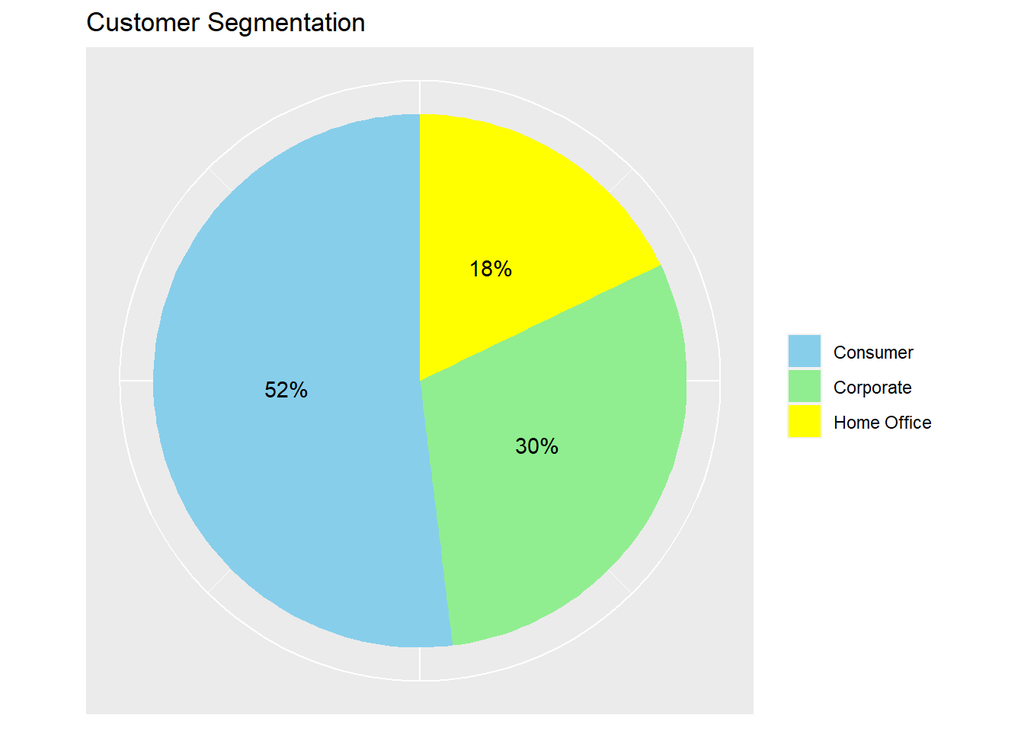

```r
customer_segments <- df %>% count(Segment)
ggplot(customer_segments, aes(x = "", y = n, fill = Segment)) +
  geom_bar(stat = "identity") +
  labs(x = NULL, y = NULL, fill = NULL, title = 'Customer Segmentation') +
  coord_polar(theta = "y") +
  scale_fill_manual(values = c("skyblue", "lightgreen", "yellow"))+
  geom_text(aes(label = scales::percent(n / sum(n))),
            position = position_stack(vjust = 0.5))+
  theme(axis.text = element_blank(),
        axis.ticks = element_blank())
```

Consumers are the highest purchasing customer segment

### Customer Churn Analysis

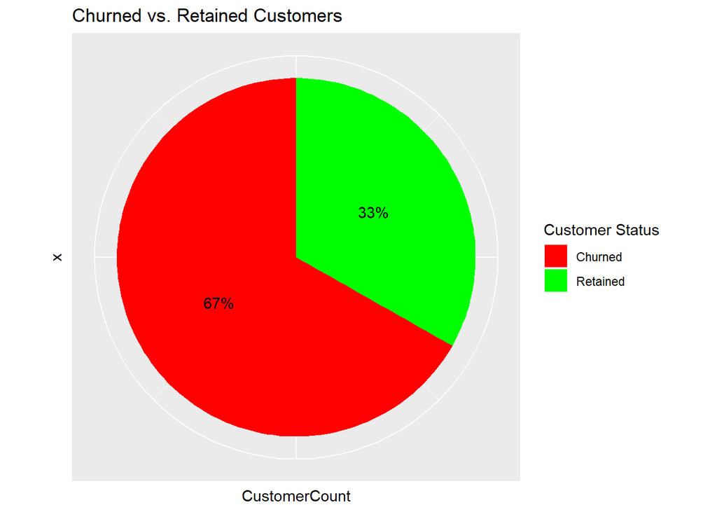

```r
# Calculate the latest order date in the dataset
latest_order_date = max(df$Order.Date)

# Define a churn threshold
churn_threshold = latest_order_date -months(12)

# Create a new column 'Churned' to identify churned customers
df = df %>%
  mutate(Churned = ifelse(Order.Date <= churn_threshold, "Churned", "Retained"))

# Create a summary table of churned vs. retained customers
churn_summary = df %>%
  group_by(Churned) %>%
  summarise(CustomerCount = n())

# Create a pie chart
ggplot(churn_summary, aes(x = "", y = CustomerCount, fill = Churned)) +
  geom_bar(stat = "identity") +
  coord_polar(theta = "y")+
  labs(title = "Churned vs. Retained Customers", fill = "Customer Status")  +
  scale_fill_manual(values = c("Churned" = "red", "Retained" = "green"))+
  geom_text(aes(label = scales::percent(CustomerCount / sum(CustomerCount))),
            position = position_stack(vjust = 0.5))+
  theme(axis.text = element_blank(),
        axis.ticks = element_blank())
```

## Conclusion

In conclusion, the SuperStore should leverage the following insights for informed decision-making:

**Seasonal Sales Emphasis:** The SuperStore should focus on capitalizing on peak holiday seasons, particularly in November and December, to maximize sales and revenue.

**Category and Product Strategy:** Prioritizing the “Technology” and “Office Supplies” categories can lead to higher profitability. Additionally, product offerings such as “Staple Envelope,” “Easy-Staple Paper,” and “Staples” have shown strong sales performance.

**Regional Targeting:** Recognizing regional variations in sales and profitability provides an opportunity to tailor marketing efforts and allocate resources effectively.

**Customer Retention:** Developing robust customer retention strategies is essential to reduce churn and retain a larger share of the customer base.

This analysis serves as a foundational step toward data-driven decision-making within the SuperStore, enabling it to enhance performance, profitability, and customer satisfaction. For more in-depth insights and advanced analysis, further exploration and modeling can be pursued, ultimately driving continued success for the SuperStore.